# Презентация по лабораторной работе №2

Дисциплина: Администрирование локальных сетей

Лобанова П.И.

Российский университет дружбы народов, Москва, Россия

20 февраля 2025

# Информация

## Докладчик

- Лобанова Полина Иннокентьевна
- Учащаяся на направлении “Фундаментальная информатика и информационные технологии”
- Студентка группы НФИбд-02-22
- polla-2004@mail.ru

# Цель

Получить основные навыки по начальному конфигурированию оборудования Cisco.

# Задание

1. Сделать предварительную настройку маршрутизатора:

– задать имя в виде «город-территория-учётная_записьтип_оборудования-номер»;

– задать интерфейсу Fast Ethernet с номером 0 ip-адрес 192.168.1.254 и маску 255.255.255.0, затем поднять интерфейс;

– задать пароль для доступа к привилегированному режиму (сначала в открытом виде, затем — в зашифрованном);

– настроить доступ к оборудованию сначала через telnet, затем — через ssh;

– сохранить и экспортировать конфигурацию в отдельный файл.

2. Сделать предварительную настройку коммутатора:

– задать имя в виде «город-территория-учётная_записьтип_оборудования-номер»;

– задать интерфейсу vlan 2 ip-адрес 192.168.2.1 и маску 255.255.255.0, затем поднять интерфейс;

– привязать интерфейс Fast Ethernet с номером 1 к vlan 2;

– задать в качестве адреса шлюза по умолчанию адрес 192.168.2.254;

– задать пароль для доступа к привилегированному режиму (сначала в открытом виде, затем — в зашифрованном);

– настроить доступ к оборудованию сначала через telnet, затем — через ssh;

– для пользователя admin задать доступ 1-го уровня по паролю;

– сохранить и экспортировать конфигурацию в отдельный файл.

# Выполнение

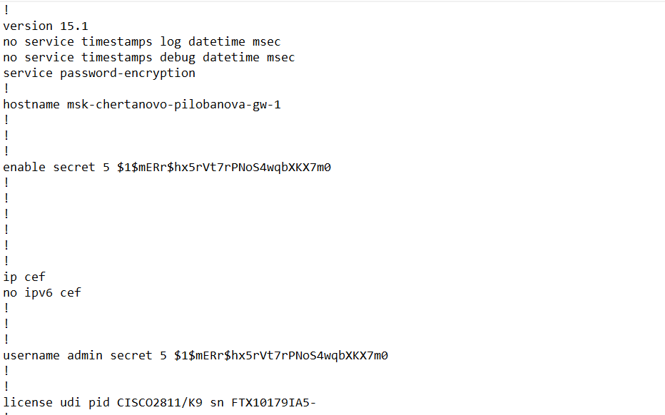

*Конфигурация маршрутизатора*

## Настройка маршрутизатора

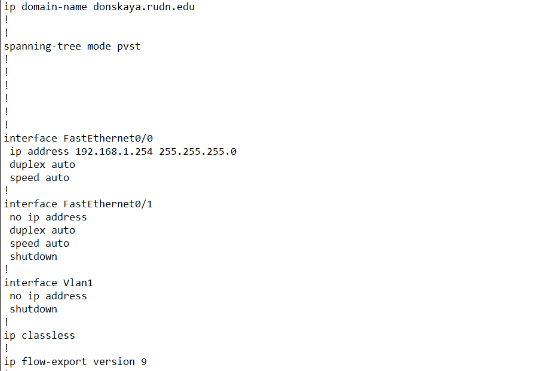

*Конфигурация маршрутизатора*

## Настройка маршрутизатора

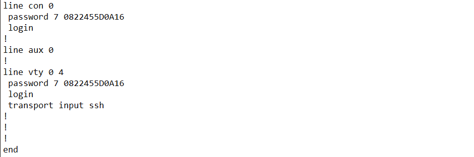

*Конфигурация маршрутизатора*

## Проверка подключения

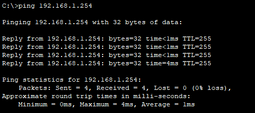

*Команда ping*

## Проверка подключения

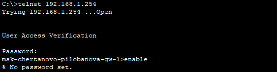

*Подключение через telnet*

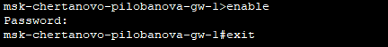

*Подключение через telnet*

## Проверка подключения

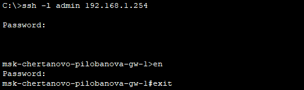

*Подключение через ssh*

## Настройка коммутатора

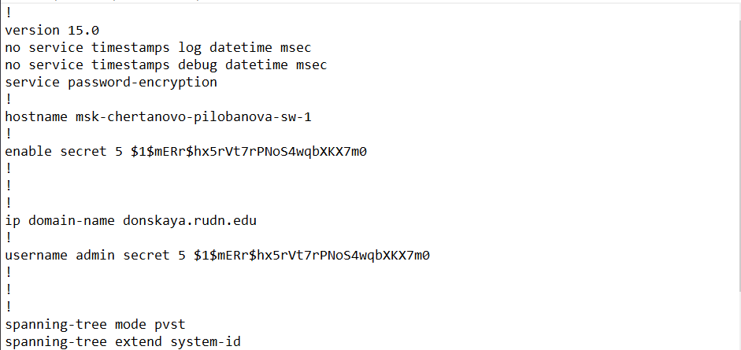

*Конфигурация коммутатора*

## Настройка коммутатора

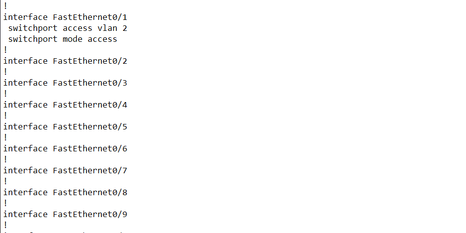

*Конфигурация коммутатора*

## Настройка коммутатора

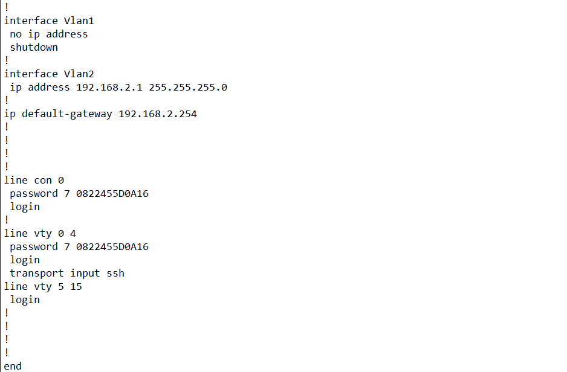

*Конфигурация коммутатора*

## Проверка подключения

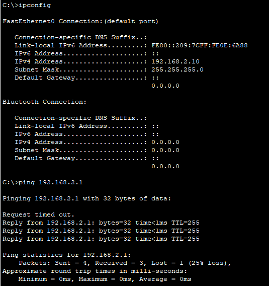

*Команда ping*

## Проверка подключения

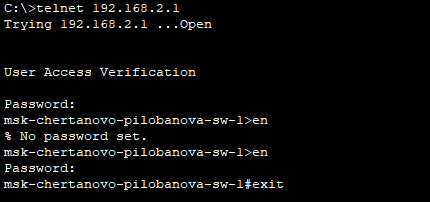

*Подключение через telnet*

## Проверка подключения

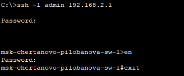

*Подключение через ssh*

# Вывод

Получить получила основные навыки по начальному конфигурированию оборудования Cisco.